# CA2 Data Visualization

Jessica Fornetti

2023-12-01

First we load the 1st data set:

```r
df1 <- read.csv("shopping_trends.csv")
View(df1)
```

Then we load the 2nd data set:

```r
df2 <- read.csv("file.csv")
View(df2)
```

Then we check to make sure the columns are assigned the right types

```r
str(df1)
```

```
## 'data.frame':    3900 obs. of  19 variables:
##  $ Customer.ID             : int  1 2 3 4 5 6 7 8 9 10 ...
##  $ Age                     : int  55 19 50 21 45 46 63 27 26 57 ...
##  $ Gender                  : chr  "Male" "Male" "Male" "Male" ...
##  $ Item.Purchased          : chr  "Blouse" "Sweater" "Jeans" "Sandals" ...
##  $ Category                : chr  "Clothing" "Clothing" "Clothing" "Footwear" ...
##  $ Purchase.Amount..USD.   : int  53 64 73 90 49 20 85 34 97 31 ...
##  $ Location                : chr  "Kentucky" "Maine" "Massachusetts" "Rhode Island" ...
##  $ Size                    : chr  "L" "L" "S" "M" ...
##  $ Color                   : chr  "Gray" "Maroon" "Maroon" "Maroon" ...
##  $ Season                  : chr  "Winter" "Winter" "Spring" "Spring" ...
##  $ Review.Rating           : num  3.1 3.1 3.1 3.5 2.7 2.9 3.2 3.2 2.6 4.8 ...
##  $ Subscription.Status     : chr  "Yes" "Yes" "Yes" "Yes" ...
##  $ Payment.Method          : chr  "Credit Card" "Bank Transfer" "Cash" "PayPal" ...
##  $ Shipping.Type           : chr  "Express" "Express" "Free Shipping" "Next Day Air" ...
##  $ Discount.Applied        : chr  "Yes" "Yes" "Yes" "Yes" ...
##  $ Promo.Code.Used         : chr  "Yes" "Yes" "Yes" "Yes" ...
##  $ Previous.Purchases      : int  14 2 23 49 31 14 49 19 8 4 ...
##  $ Preferred.Payment.Method: chr  "Venmo" "Cash" "Credit Card" "PayPal" ...
##  $ Frequency.of.Purchases  : chr  "Fortnightly" "Fortnightly" "Weekly" "Weekly" ...
```

Most of the character type columns should be factors instead, so we convert those columns to the right type:

```r
columns <- c('Gender', 'Item.Purchased', 'Category', 'Location', 'Size', 'Color', 'Season', 'Subscription.Status', 'Payment.Method', 'Shipping.Type', 'Discount.Applied', 'Promo.Code.Used', 'Preferred.Payment.Method', 'Frequency.of.Purchases')

for (col in columns) {
  df1[, col] <- as.factor(df1[, col])
}

str(df1)
```

```
## 'data.frame':    3900 obs. of  19 variables:
##  $ Customer.ID             : int  1 2 3 4 5 6 7 8 9 10 ...
##  $ Age                     : int  55 19 50 21 45 46 63 27 26 57 ...
##  $ Gender                  : Factor w/ 2 levels "Female","Male": 2 2 2 2 2 2 2 2 2 2 ...
##  $ Item.Purchased          : Factor w/ 25 levels "Backpack","Belt",..: 3 24 12 15 3 21 17 19 5 8 ...
##  $ Category                : Factor w/ 4 levels "Accessories",..: 2 2 2 3 2 3 2 2 4 1 ...
##  $ Purchase.Amount..USD.   : int  53 64 73 90 49 20 85 34 97 31 ...
##  $ Location                : Factor w/ 50 levels "Alabama","Alaska",..: 17 19 21 39 37 50 26 18 48 25 ...
##  $ Size                    : Factor w/ 4 levels "L","M","S","XL": 1 1 3 2 2 2 2 1 1 2 ...
##  $ Color                   : Factor w/ 25 levels "Beige","Black",..: 8 13 13 13 22 24 8 5 20 17 ...
##  $ Season                  : Factor w/ 4 levels "Fall","Spring",..: 4 4 2 2 2 3 1 4 3 2 ...
##  $ Review.Rating           : num  3.1 3.1 3.1 3.5 2.7 2.9 3.2 3.2 2.6 4.8 ...
##  $ Subscription.Status     : Factor w/ 2 levels "No","Yes": 2 2 2 2 2 2 2 2 2 2 ...
##  $ Payment.Method          : Factor w/ 6 levels "Bank Transfer",..: 3 1 2 5 2 6 4 4 6 5 ...
##  $ Shipping.Type           : Factor w/ 6 levels "2-Day Shipping",..: 2 2 3 4 3 5 3 3 2 1 ...
##  $ Discount.Applied        : Factor w/ 2 levels "No","Yes": 2 2 2 2 2 2 2 2 2 2 ...
##  $ Promo.Code.Used         : Factor w/ 2 levels "No","Yes": 2 2 2 2 2 2 2 2 2 2 ...
##  $ Previous.Purchases      : int  14 2 23 49 31 14 49 19 8 4 ...
##  $ Preferred.Payment.Method: Factor w/ 6 levels "Bank Transfer",..: 6 2 3 5 5 6 2 3 6 2 ...
##  $ Frequency.of.Purchases  : Factor w/ 7 levels "Annually","Bi-Weekly",..: 4 4 7 7 1 7 6 7 1 6 ...
```

Now we can check the types for the second data set:

```r
str(df2)
```

```
## 'data.frame':    52955 obs. of  21 variables:
##  $ X                  : int  0 1 2 3 4 5 6 7 8 9 ...
##  $ CustomerID         : num  17850 17850 17850 17850 17850 ...
##  $ Gender             : chr  "M" "M" "M" "M" ...
##  $ Location           : chr  "Chicago" "Chicago" "Chicago" "Chicago" ...
##  $ Tenure_Months      : num  12 12 12 12 12 12 12 12 12 12 ...
##  $ Transaction_ID     : num  16679 16680 16696 16699 16700 ...
##  $ Transaction_Date   : chr  "2019-01-01" "2019-01-01" "2019-01-01" "2019-01-01" ...
##  $ Product_SKU        : chr  "GGOENEBJ079499" "GGOENEBJ079499" "GGOENEBQ078999" "GGOENEBQ079099" ...
##  $ Product_Description: chr  "Nest Learning Thermostat 3rd Gen-USA - Stainless Steel" "Nest Learning Thermostat 3rd Gen-USA - Stainless Steel" "Nest Cam Outdoor Security Camera - USA" "Nest Protect Smoke + CO White Battery Alarm-USA" ...
##  $ Product_Category   : chr  "Nest-USA" "Nest-USA" "Nest-USA" "Nest-USA" ...
##  $ Quantity           : num  1 1 2 1 1 1 2 2 1 1 ...
##  $ Avg_Price          : num  153.7 153.7 122.8 81.5 153.7 ...
##  $ Delivery_Charges   : num  6.5 6.5 6.5 6.5 6.5 ...
##  $ Coupon_Status      : chr  "Used" "Used" "Not Used" "Clicked" ...
##  $ GST                : num  0.1 0.1 0.1 0.1 0.1 0.1 0.1 0.1 0.1 0.1 ...
##  $ Date               : chr  "1/1/2019" "1/1/2019" "1/1/2019" "1/1/2019" ...
##  $ Offline_Spend      : num  4500 4500 4500 4500 4500 4500 4500 4500 4500 4500 ...
##  $ Online_Spend       : num  2424 2424 2424 2424 2424 ...
##  $ Month              : int  1 1 1 1 1 1 1 1 1 1 ...
##  $ Coupon_Code        : chr  "ELEC10" "ELEC10" "ELEC10" "ELEC10" ...
##  $ Discount_pct       : num  10 10 10 10 10 10 10 10 10 10 ...
```

Similarly, we need to convert some character columns to factor columns:

```r
columns <- c('Gender', 'Location', 'Product_Category', 'Coupon_Status')

for (col in columns) {
  df2[, col] <- as.factor(df2[, col])
}

str(df2)
```

```
## 'data.frame':    52955 obs. of  21 variables:
##  $ X                  : int  0 1 2 3 4 5 6 7 8 9 ...
##  $ CustomerID         : num  17850 17850 17850 17850 17850 ...
##  $ Gender             : Factor w/ 3 levels "","F","M": 3 3 3 3 3 3 3 3 3 3 ...
##  $ Location           : Factor w/ 6 levels "","California",..: 3 3 3 3 3 3 3 3 3 3 ...
##  $ Tenure_Months      : num  12 12 12 12 12 12 12 12 12 12 ...
##  $ Transaction_ID     : num  16679 16680 16696 16699 16700 ...
##  $ Transaction_Date   : chr  "2019-01-01" "2019-01-01" "2019-01-01" "2019-01-01" ...
##  $ Product_SKU        : chr  "GGOENEBJ079499" "GGOENEBJ079499" "GGOENEBQ078999" "GGOENEBQ079099" ...
##  $ Product_Description: chr  "Nest Learning Thermostat 3rd Gen-USA - Stainless Steel" "Nest Learning Thermostat 3rd Gen-USA - Stainless Steel" "Nest Cam Outdoor Security Camera - USA" "Nest Protect Smoke + CO White Battery Alarm-USA" ...
##  $ Product_Category   : Factor w/ 21 levels "Accessories",..: 17 17 17 17 17 17 17 17 17 17 ...
##  $ Quantity           : num  1 1 2 1 1 1 2 2 1 1 ...
##  $ Avg_Price          : num  153.7 153.7 122.8 81.5 153.7 ...
##  $ Delivery_Charges   : num  6.5 6.5 6.5 6.5 6.5 ...
##  $ Coupon_Status      : Factor w/ 4 levels "","Clicked","Not Used",..: 4 4 3 2 2 2 2 3 4 2 ...
##  $ GST                : num  0.1 0.1 0.1 0.1 0.1 0.1 0.1 0.1 0.1 0.1 ...
##  $ Date               : chr  "1/1/2019" "1/1/2019" "1/1/2019" "1/1/2019" ...
##  $ Offline_Spend      : num  4500 4500 4500 4500 4500 4500 4500 4500 4500 4500 ...
##  $ Online_Spend       : num  2424 2424 2424 2424 2424 ...
##  $ Month              : int  1 1 1 1 1 1 1 1 1 1 ...
##  $ Coupon_Code        : chr  "ELEC10" "ELEC10" "ELEC10" "ELEC10" ...
##  $ Discount_pct       : num  10 10 10 10 10 10 10 10 10 10 ...
```

Then we need to check if our data sets contain any missing values. We count the number of missing values per column:

```r
missing_values_per_column <- sapply(df1, function(x) sum(is.na(x)))
missing_values_per_column
```

```
##              Customer.ID                      Age                   Gender
##                        0                        0                        0
##           Item.Purchased                 Category    Purchase.Amount..USD.
##                        0                        0                        0
##                 Location                     Size                    Color
##                        0                        0                        0
##                   Season            Review.Rating      Subscription.Status
##                        0                        0                        0
##           Payment.Method            Shipping.Type         Discount.Applied
##                        0                        0                        0
##          Promo.Code.Used       Previous.Purchases Preferred.Payment.Method
##                        0                        0                        0
##   Frequency.of.Purchases
##                        0
```

The 1st data set has no missing values. We do the same thing for df2:

```r
missing_values_per_column2 <- sapply(df2, function(x) sum(is.na(x)))
missing_values_per_column2
```

```
##                   X          CustomerID              Gender            Location
##                   0                  31                   0                   0
##       Tenure_Months      Transaction_ID    Transaction_Date         Product_SKU
##                  31                  31                   0                   0
## Product_Description    Product_Category            Quantity           Avg_Price
##                   0                   0                  31                  31
##    Delivery_Charges       Coupon_Status                 GST                Date
##                  31                   0                  31                   0
##       Offline_Spend        Online_Spend               Month         Coupon_Code
##                  31                  31                   0                   0
##        Discount_pct
##                 400
```

The 2nd data set has 10 columns containing missing values. We can get all the rows containing Nas :

```r
rows_with_nas <- df2[!complete.cases(df2), ]
rows_with_nas
```

```
##           X CustomerID Gender      Location Tenure_Months Transaction_ID
## 3896   3895      17850      M       Chicago            12          16704
## 3897   3896      17850      M       Chicago            12          18076
## 3898   3897      14060      F       Chicago            22          18459
## 3899   3898      15061      M    California             7          18896
## 3900   3899      18074      F    California            10          16782
## 3901   3900      16029      F Washington DC            40          16800
## 3902   3901      17968      M      New York            33          17217
## 3903   3902      12433      M    California            32          17516
## 3904   3903      12433      M    California            32          17541
## 3905   3904      15646      M    California            10          19119
## 3906   3905      17964      M    New Jersey             5          18657
## 3961   3960      13448      F    California            41          16903
## 3962   3961      17920      F    California            18          17093
## 3963   3962      17850      M       Chicago            12          18031
```

[output cut: 2145 more lines]

```r
dim(df2)
```

```
## [1] 52955    21
```

There are only 431 rows containing missing values, while the entire data set has 52955 rows of data, so we can just drop these rows as we have lots of data.

However first we look at the Nas in specific columns, to get a better idea of the Nas :

```r
rows_with_nas_in_customerid <- df2[is.na(df2[, 'CustomerID']), ]
rows_with_nas_in_customerid
```

```
##           X CustomerID Gender Location Tenure_Months Transaction_ID
## 52925 52924         NA                            NA             NA
## 52926 52925         NA                            NA             NA
## 52927 52926         NA                            NA             NA
## 52928 52927         NA                            NA             NA
## 52929 52928         NA                            NA             NA
## 52930 52929         NA                            NA             NA
## 52931 52930         NA                            NA             NA
## 52932 52931         NA                            NA             NA
## 52933 52932         NA                            NA             NA
## 52934 52933         NA                            NA             NA
## 52935 52934         NA                            NA             NA
## 52936 52935         NA                            NA             NA
## 52937 52936         NA                            NA             NA
## 52938 52937         NA                            NA             NA
```

[output cut: 113 more lines]

We can notice that the 31 rows containing Nas, have Nas in all 10 columns therefore these rows are not of much use, so we can drop them.

```r
df2 <- df2[complete.cases(df2[, 'CustomerID']), ]
```

We check that the Nas have been removed:

```r
missing_values_per_column2 <- sapply(df2, function(x) sum(is.na(x)))
missing_values_per_column2
```

```
##                   X          CustomerID              Gender            Location
##                   0                   0                   0                   0
##       Tenure_Months      Transaction_ID    Transaction_Date         Product_SKU
##                   0                   0                   0                   0
## Product_Description    Product_Category            Quantity           Avg_Price
##                   0                   0                   0                   0
##    Delivery_Charges       Coupon_Status                 GST                Date
##                   0                   0                   0                   0
##       Offline_Spend        Online_Spend               Month         Coupon_Code
##                   0                   0                   0                   0
##        Discount_pct
##                 400
```

Then lets look at the remaining 400 rows with Nas in the Discount_pct column:

```r
rows_with_nas_in_discount_pct <- df2[is.na(df2[, 'Discount_pct']), ]
rows_with_nas_in_discount_pct
```

```
##           X CustomerID Gender      Location Tenure_Months Transaction_ID
## 3896   3895      17850      M       Chicago            12          16704
## 3897   3896      17850      M       Chicago            12          18076
## 3898   3897      14060      F       Chicago            22          18459
## 3899   3898      15061      M    California             7          18896
## 3900   3899      18074      F    California            10          16782
## 3901   3900      16029      F Washington DC            40          16800
## 3902   3901      17968      M      New York            33          17217
## 3903   3902      12433      M    California            32          17516
## 3904   3903      12433      M    California            32          17541
## 3905   3904      15646      M    California            10          19119
## 3906   3905      17964      M    New Jersey             5          18657
## 3961   3960      13448      F    California            41          16903
## 3962   3961      17920      F    California            18          17093
## 3963   3962      17850      M       Chicago            12          18031
```

[output cut: 1990 more lines]

All these rows contain values in the other 20 columns, so we won’t drop these rows given that they are only missing the coupon related information.

For df2, we will drop the X column as it does not provide any extra information (just an indexing column), and we will rename the columns similarly to df1’s naming:

```r
df2 <- df2[, !colnames(df2) %in% 'X']
View(df2)
```

```r
new_column_names <- c("Customer.ID", "Gender", "Location", 'Tenure.Months', 'Transaction.ID', 'Transaction.Date', 'Product.SKU', 'Product.Description', 'Product.Category', 'Quantity', 'Avg.Price', 'Delivery.Charges', 'Coupon.Status', 'GST', 'Date', 'Offline.Spend', 'Online.Spend', 'Month', 'Coupon.Code', 'Disount.Pct')
colnames(df2) <- new_column_names
View(df2)
```

We import the libraries needed:

```r
library(ggplot2)
library(sqldf)
library(maps)
library(reshape2)
```

Now we move on to the exploratory analysis:  
First lets concentrate on df1:  
Lets look at the variables that might influence customers spending habits: Gender and Age.

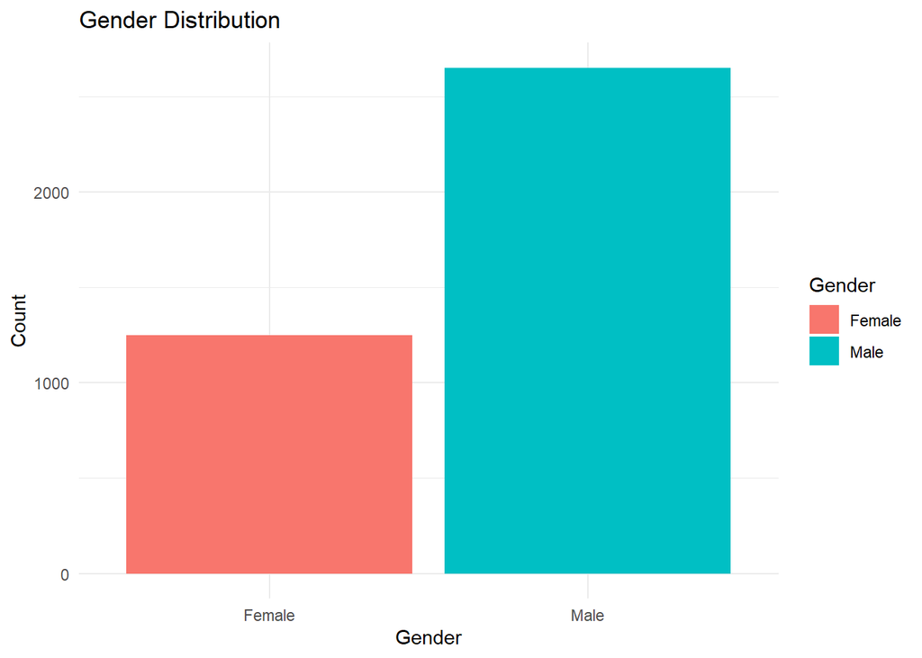

```r
#Queries for df1
#Count by gender
gender<-sqldf("select Gender, count(Gender) as count from df1 group by Gender")
#View(gender)

ggplot(gender, aes(x = Gender, y = count, fill = Gender)) +
  geom_bar(stat = "identity") +
  labs(title = "Gender Distribution", x = "Gender", y = "Count") +
  theme_minimal()
```

We can notice that the data set is unbalanced and there is 2 times more men in the data set.

For age we can observe the distribution using a histogram:

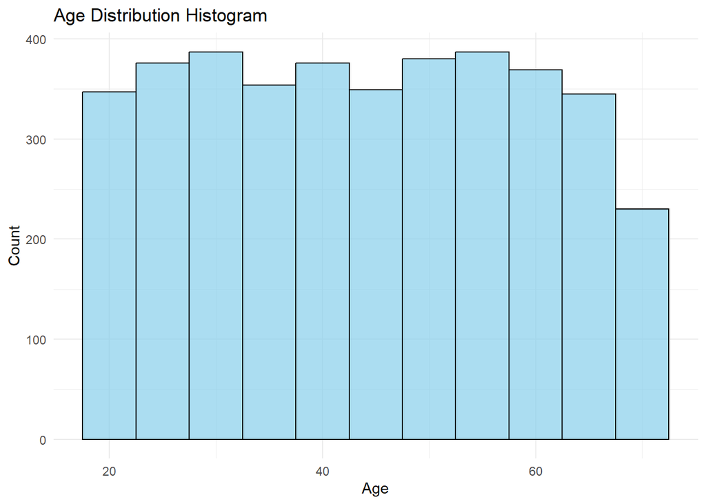

```r
ggplot(df1, aes(x = Age)) +
  geom_histogram(binwidth = 5, fill = "skyblue", color = "black", alpha = 0.7) +
  labs(title = "Age Distribution Histogram", x = "Age", y = "Count") +
  theme_minimal()
```

We can see that the data set contains a similar amount of people from different age groups (except for the older 60+ group).

So we can divide our age groups as the following:

```r
#First we get the min and max age
min_age <- min(df1[['Age']])
max_age <- max(df1[['Age']])
min_age
```

```
## [1] 18
```

```r
max_age
```

```
## [1] 70
```

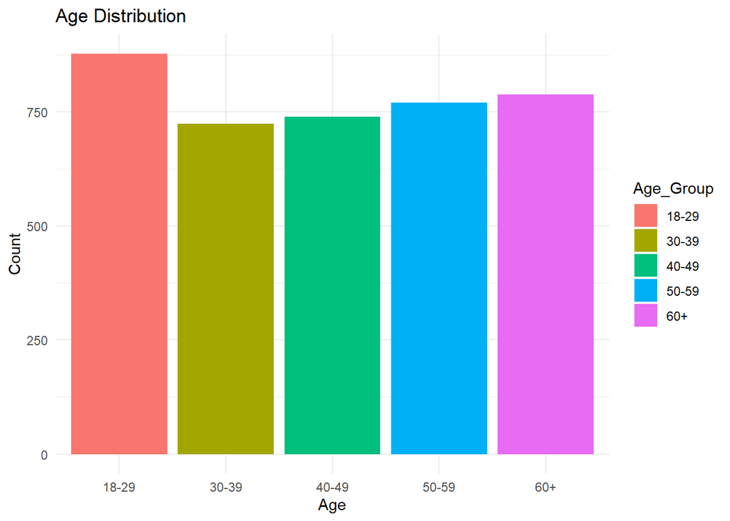

```r
#Count by age, we define our age groups 18 to 29, 30 to 39, ... and 60+
age<-sqldf("select case when Age between 18 and 29 then '18-29' when Age between 30 and 39 then '30-39' when Age between 40 and 49 then '40-49' when Age between 50 and 59 then '50-59' else '60+' end as Age_Group, count(*) as count from df1 group by Age_Group")
#View(age)

ggplot(age, aes(x = Age_Group, y = count, fill = Age_Group)) +
  geom_bar(stat = "identity") +
  labs(title = "Age Distribution", x = "Age", y = "Count") +
  theme_minimal()
```

When choosing these Age groups, we divide the customers evenly.

Now lets look at the top purchases by Categroy and Item purchased:

```r
#Top purchases, we count the amount of a specific item purchased and the average price for each category, ordering by the most purchased item for each category.
top_purchases<-sqldf("select Category, `Item.Purchased`, count(`Item.Purchased`) as count,  avg(`Purchase.Amount..USD.`) as avg_price from df1 group by `Item.Purchased` order by Category, count desc")
#View(top_purchases)
```

We can plot the most purchased items for each category:

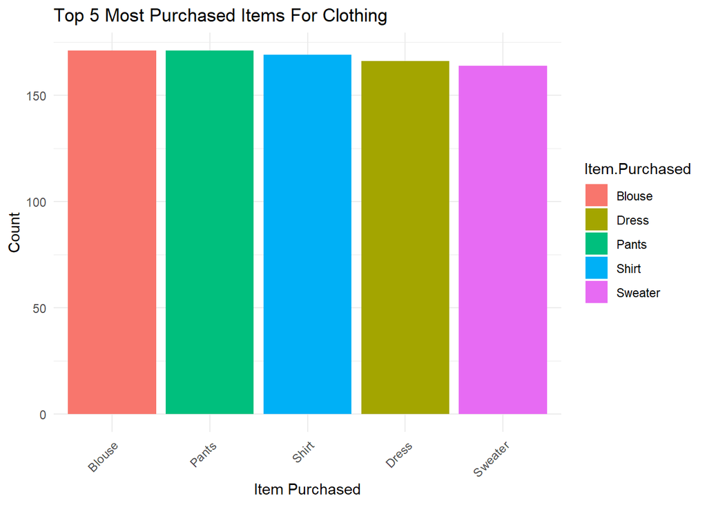

```r
top_5_clothing<-sqldf("select Category, `Item.Purchased`, count(`Item.Purchased`) as count,  avg(`Purchase.Amount..USD.`) as avg_price from df1 where Category == 'Clothing' group by `Item.Purchased` order by count desc limit 5")
#View(top_5_clothing)

ggplot(top_5_clothing, aes(x = reorder(`Item.Purchased`, -count), y = count, fill = `Item.Purchased`)) +
  geom_bar(stat = "identity") +
  labs(title = "Top 5 Most Purchased Items For Clothing", x = "Item Purchased", y = "Count") +
  theme_minimal() +
  theme(axis.text.x = element_text(angle = 45, hjust = 1))
```

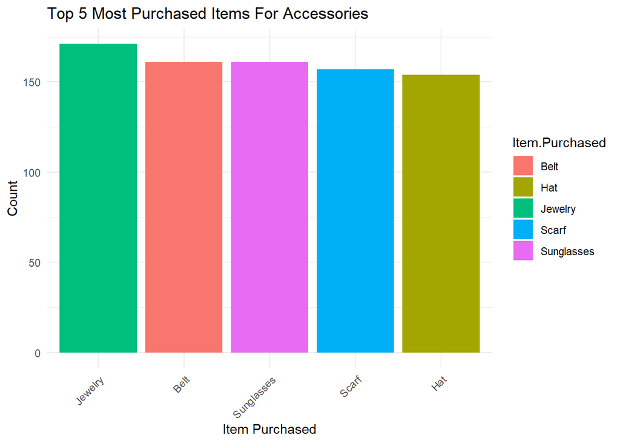

```r
top_5_accessories<-sqldf("select Category, `Item.Purchased`, count(`Item.Purchased`) as count,  avg(`Purchase.Amount..USD.`) as avg_price from df1 where Category == 'Accessories' group by `Item.Purchased` order by count desc limit 5")
#View(top_5_accessories)

ggplot(top_5_accessories, aes(x = reorder(`Item.Purchased`, -count), y = count, fill = `Item.Purchased`)) +
  geom_bar(stat = "identity") +
  labs(title = "Top 5 Most Purchased Items For Accessories", x = "Item Purchased", y = "Count") +
  theme_minimal() +
  theme(axis.text.x = element_text(angle = 45, hjust = 1))
```

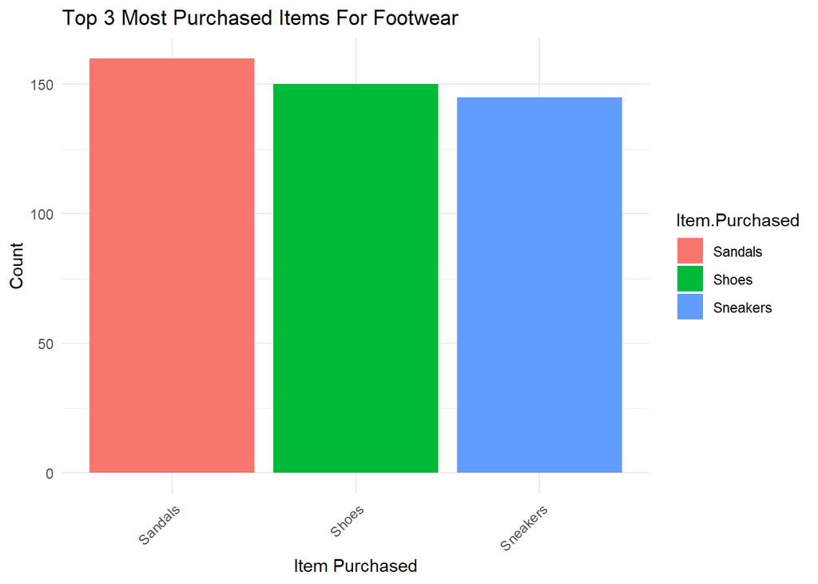

```r
top_3_footwear<-sqldf("select Category, `Item.Purchased`, count(`Item.Purchased`) as count,  avg(`Purchase.Amount..USD.`) as avg_price from df1 where Category == 'Footwear' group by `Item.Purchased` order by count desc limit 3")
#View(top_3_footwear)

ggplot(top_3_footwear, aes(x = reorder(`Item.Purchased`, -count), y = count, fill = `Item.Purchased`)) +
  geom_bar(stat = "identity") +
  labs(title = "Top 3 Most Purchased Items For Footwear", x = "Item Purchased", y = "Count") +
  theme_minimal() +
  theme(axis.text.x = element_text(angle = 45, hjust = 1))
```

We can see how this varies by Gender and Age:

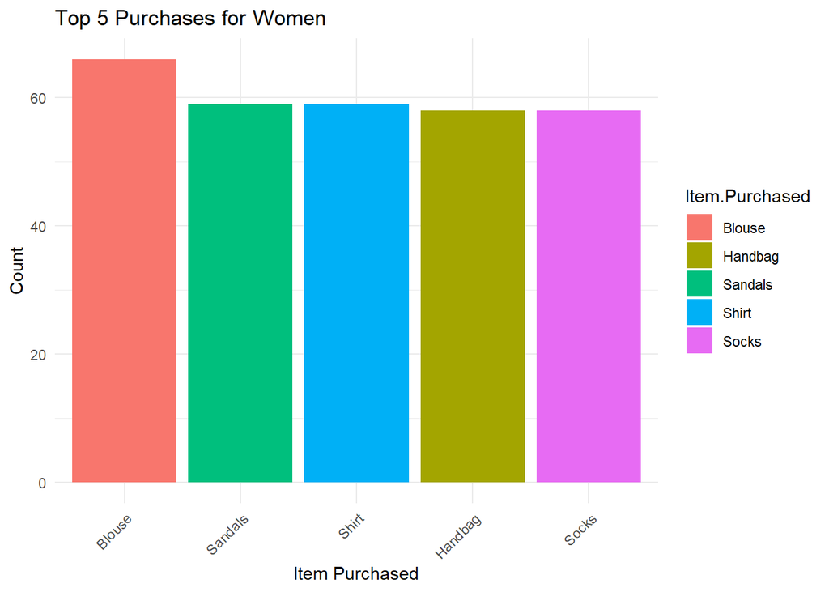

```r
#First we look at the top 5 purchases for women:
top_5_purchases_women<-sqldf("select Category, `Item.Purchased`, count(`Item.Purchased`) as count,  avg(`Purchase.Amount..USD.`) as avg_price from df1 where Gender == 'Female' group by `Item.Purchased` order by count desc limit 5")
#View(top_5_purchases_women)

ggplot(top_5_purchases_women, aes(x = reorder(`Item.Purchased`, -count), y = count, fill = `Item.Purchased`)) +
  geom_bar(stat = "identity") +
  labs(title = "Top 5 Purchases for Women", x = "Item Purchased", y = "Count") +
  theme_minimal() +
  theme(axis.text.x = element_text(angle = 45, hjust = 1))
```

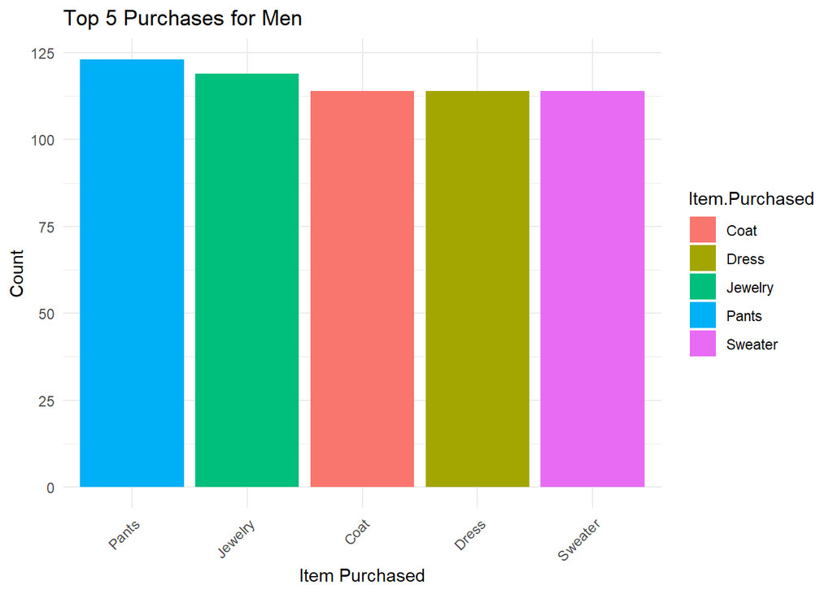

```r
#Then we compare to the top 5 purchases for men:
top_5_purchases_men<-sqldf("select Category, `Item.Purchased`, count(`Item.Purchased`) as count,  avg(`Purchase.Amount..USD.`) as avg_price from df1 where Gender == 'Male' group by `Item.Purchased` order by count desc limit 5")
#View(top_5_purchases_men)

ggplot(top_5_purchases_men, aes(x = reorder(`Item.Purchased`, -count), y = count, fill = `Item.Purchased`)) +
  geom_bar(stat = "identity") +
  labs(title = "Top 5 Purchases for Men", x = "Item Purchased", y = "Count") +
  theme_minimal() +
  theme(axis.text.x = element_text(angle = 45, hjust = 1))
```

The most purchased items for women are blouse, sandals, shirt, handbag and socks, while the most purchased for men are pants, jewelry, coat, dress and sweater. (Jewelry and dress might seem surprising, but they could have been bought as a gift for someone else.)

We can look at how this varies for age:

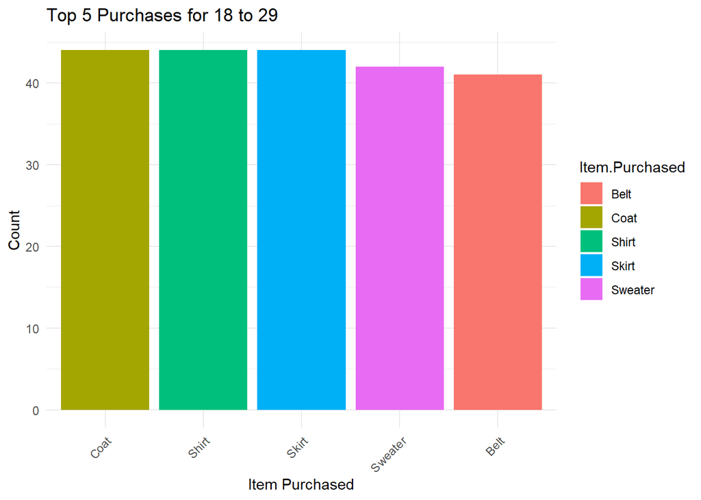

```r
#We have all the purchases in descending order for each age group
purchases_by_age<-sqldf("select case when Age between 18 and 29 then '18-29' when Age between 30 and 39 then '30-39' when Age between 40 and 49 then '40-49' when Age between 50 and 59 then '50-59' else '60+' end as Age_Group, Category, `Item.Purchased`, count(`Item.Purchased`) as count,  avg(`Purchase.Amount..USD.`) as avg_price from df1 group by Age_Group, `Item.Purchased` order by Age_Group, count desc")
#View(purchases_by_age)

#We have the top 5 purchases for the 18 to 29 age group.
top_5_purchases_18_29<-sqldf("select Category, `Item.Purchased`, count(`Item.Purchased`) as count,  avg(`Purchase.Amount..USD.`) as avg_price from df1 where Age between 18 and 29 group by `Item.Purchased` order by count desc limit 5")
#View(top_5_purchases_18_29)

ggplot(top_5_purchases_18_29, aes(x = reorder(`Item.Purchased`, -count), y = count, fill = `Item.Purchased`)) +
  geom_bar(stat = "identity") +
  labs(title = "Top 5 Purchases for 18 to 29", x = "Item Purchased", y = "Count") +
  theme_minimal() +
  theme(axis.text.x = element_text(angle = 45, hjust = 1))
```

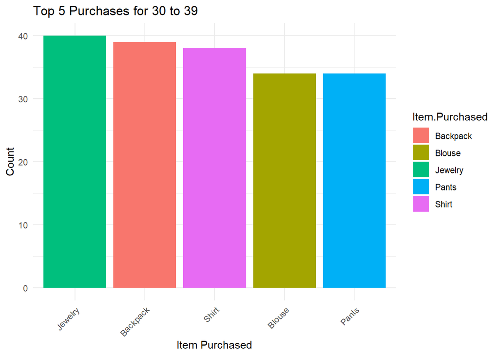

```r
#Top 5 purchases for the 30 to 39 age group.
top_5_purchases_30_39<-sqldf("select Category, `Item.Purchased`, count(`Item.Purchased`) as count,  avg(`Purchase.Amount..USD.`) as avg_price from df1 where Age between 30 and 39 group by `Item.Purchased` order by count desc limit 5")
#View(top_5_purchases_30_39)

ggplot(top_5_purchases_30_39, aes(x = reorder(`Item.Purchased`, -count), y = count, fill = `Item.Purchased`)) +
  geom_bar(stat = "identity") +
  labs(title = "Top 5 Purchases for 30 to 39", x = "Item Purchased", y = "Count") +
  theme_minimal() +
  theme(axis.text.x = element_text(angle = 45, hjust = 1))
```

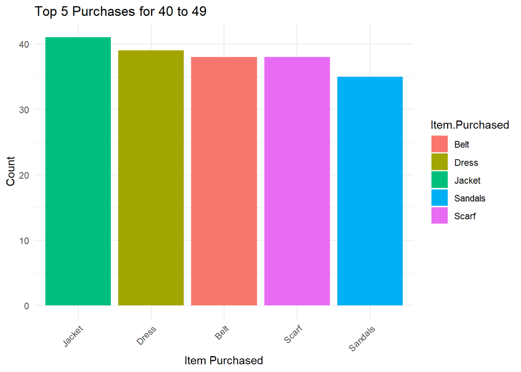

```r
#Top 5 purchases for the 40 to 49 age group.
top_5_purchases_40_49<-sqldf("select Category, `Item.Purchased`, count(`Item.Purchased`) as count,  avg(`Purchase.Amount..USD.`) as avg_price from df1 where Age between 40 and 49 group by `Item.Purchased` order by count desc limit 5")
#View(top_5_purchases_40_49)

ggplot(top_5_purchases_40_49, aes(x = reorder(`Item.Purchased`, -count), y = count, fill = `Item.Purchased`)) +
  geom_bar(stat = "identity") +
  labs(title = "Top 5 Purchases for 40 to 49", x = "Item Purchased", y = "Count") +
  theme_minimal() +
  theme(axis.text.x = element_text(angle = 45, hjust = 1))
```

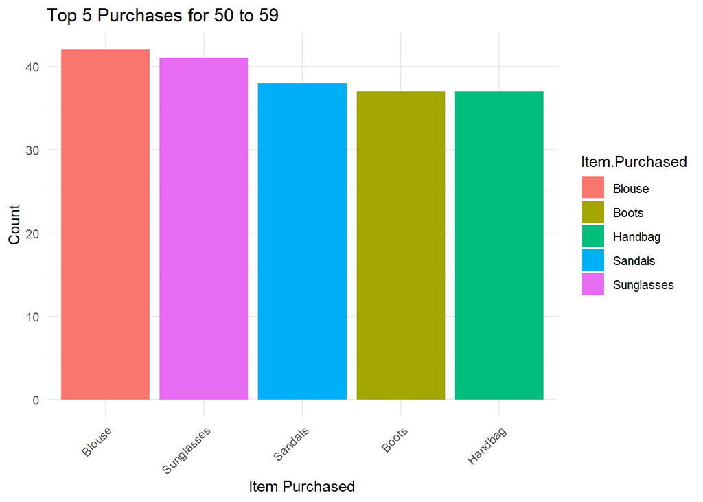

```r
#Top 5 purchases for the 50 to 59 age group.
top_5_purchases_50_59<-sqldf("select Category, `Item.Purchased`, count(`Item.Purchased`) as count,  avg(`Purchase.Amount..USD.`) as avg_price from df1 where Age between 50 and 59 group by `Item.Purchased` order by count desc limit 5")
#View(top_5_purchases_50_59)

ggplot(top_5_purchases_50_59, aes(x = reorder(`Item.Purchased`, -count), y = count, fill = `Item.Purchased`)) +
  geom_bar(stat = "identity") +
  labs(title = "Top 5 Purchases for 50 to 59", x = "Item Purchased", y = "Count") +
  theme_minimal() +
  theme(axis.text.x = element_text(angle = 45, hjust = 1))
```

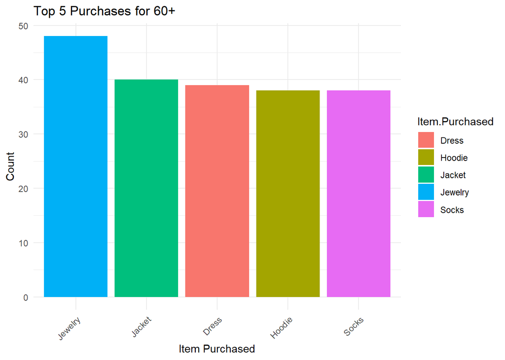

```r
#Top 5 purchases for the 60+ age group.
top_5_purchases_60<-sqldf("select Category, `Item.Purchased`, count(`Item.Purchased`) as count,  avg(`Purchase.Amount..USD.`) as avg_price from df1 where Age >= 60 group by `Item.Purchased` order by count desc limit 5")
#View(top_5_purchases_60)

ggplot(top_5_purchases_60, aes(x = reorder(`Item.Purchased`, -count), y = count, fill = `Item.Purchased`)) +
  geom_bar(stat = "identity") +
  labs(title = "Top 5 Purchases for 60+", x = "Item Purchased", y = "Count") +
  theme_minimal() +
  theme(axis.text.x = element_text(angle = 45, hjust = 1))
```

We can see that the purchases change a lot depending on which age group is purchasing the items.

We can also see how the purchases vary when looking at both gender and age:

```r
#We have the top purchases for women grouped by age
purchases_by_age_women<-sqldf("select case when Age between 18 and 29 then '18-29' when Age between 30 and 39 then '30-39' when Age between 40 and 49 then '40-49' when Age between 50 and 59 then '50-59' else '60+' end as Age_Group, Gender, Category, `Item.Purchased`, count(`Item.Purchased`),  avg(`Purchase.Amount..USD.`) as avg_price from df1 where Gender == 'Female' group by Age_Group, `Item.Purchased` order by Age_Group, count(`Item.Purchased`) desc")
#View(purchases_by_age_women)

#And the top purchases for men grouped by age
purchases_by_age_men<-sqldf("select case when Age between 18 and 29 then '18-29' when Age between 30 and 39 then '30-39' when Age between 40 and 49 then '40-49' when Age between 50 and 59 then '50-59' else '60+' end as Age_Group, Gender, Category, `Item.Purchased`, count(`Item.Purchased`),  avg(`Purchase.Amount..USD.`) as avg_price from df1 where Gender == 'Male' group by Age_Group, `Item.Purchased` order by Age_Group, count(`Item.Purchased`) desc")
#View(purchases_by_age_men)
```

We can plot the following graphs by gender and age group:

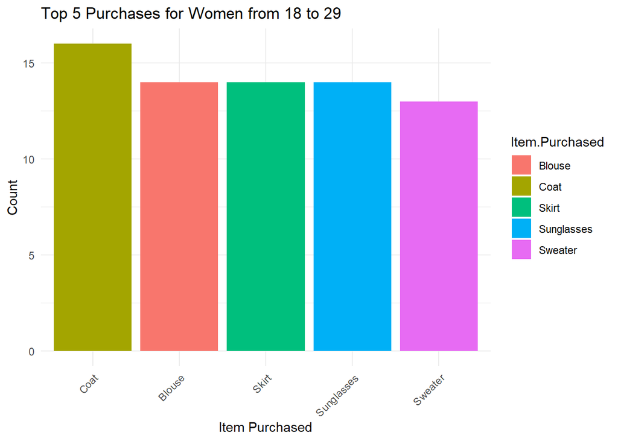

```r
#For women
#Top 5 purchases for women in the 18 to 29 age group.
top_5_purchases_women_18_29<-sqldf("select Category, `Item.Purchased`, count(`Item.Purchased`) as count,  avg(`Purchase.Amount..USD.`) as avg_price from df1 where (Age between 18 and 29) and Gender == 'Female' group by `Item.Purchased` order by count desc limit 5")
#View(top_5_purchases_women_18_29)

ggplot(top_5_purchases_women_18_29, aes(x = reorder(`Item.Purchased`, -count), y = count, fill = `Item.Purchased`)) +
  geom_bar(stat = "identity") +
  labs(title = "Top 5 Purchases for Women from 18 to 29", x = "Item Purchased", y = "Count") +
  theme_minimal() +
  theme(axis.text.x = element_text(angle = 45, hjust = 1))
```

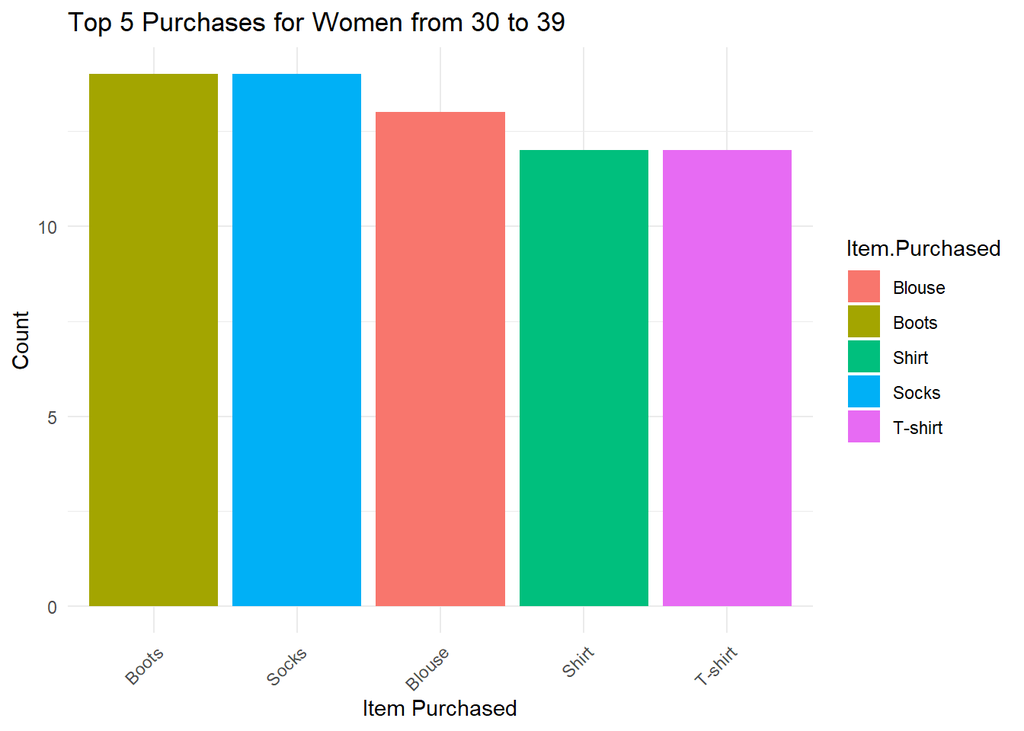

```r
#Top 5 purchases for women in the 30 to 39 age group.
top_5_purchases_women_30_39<-sqldf("select Category, `Item.Purchased`, count(`Item.Purchased`) as count,  avg(`Purchase.Amount..USD.`) as avg_price from df1 where (Age between 30 and 39) and Gender == 'Female' group by `Item.Purchased` order by count desc limit 5")
#View(top_5_purchases_women_30_39)

ggplot(top_5_purchases_women_30_39, aes(x = reorder(`Item.Purchased`, -count), y = count, fill = `Item.Purchased`)) +
  geom_bar(stat = "identity") +
  labs(title = "Top 5 Purchases for Women from 30 to 39", x = "Item Purchased", y = "Count") +
  theme_minimal() +
  theme(axis.text.x = element_text(angle = 45, hjust = 1))
```

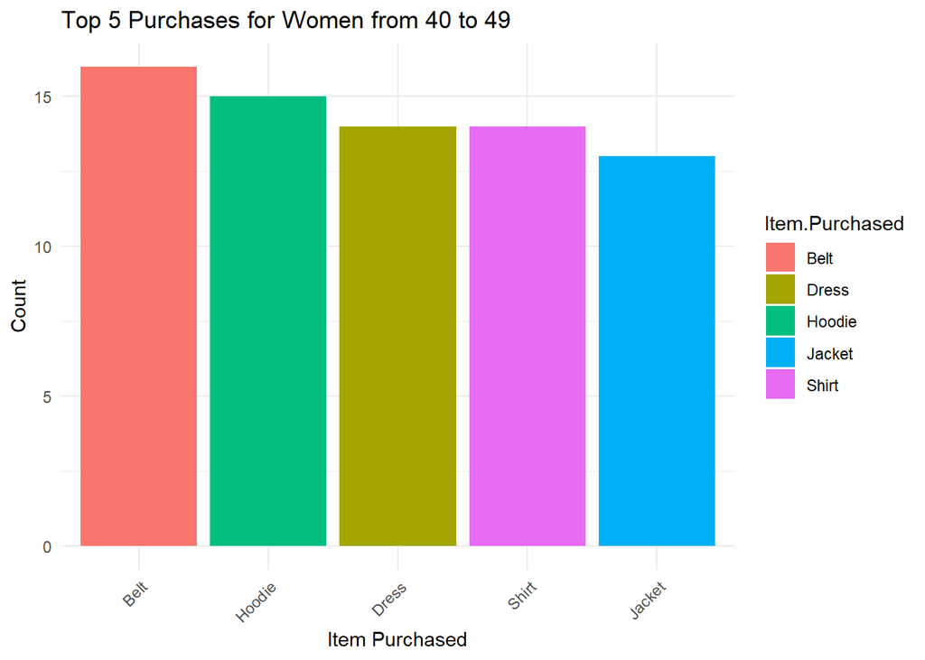

```r
#Top 5 purchases for women in the 40 to 49 age group.
top_5_purchases_women_40_49<-sqldf("select Category, `Item.Purchased`, count(`Item.Purchased`) as count,  avg(`Purchase.Amount..USD.`) as avg_price from df1 where (Age between 40 and 49) and Gender=='Female' group by `Item.Purchased` order by count desc limit 5")
#View(top_5_purchases_women_40_49)

ggplot(top_5_purchases_women_40_49, aes(x = reorder(`Item.Purchased`, -count), y = count, fill = `Item.Purchased`)) +
  geom_bar(stat = "identity") +
  labs(title = "Top 5 Purchases for Women from 40 to 49", x = "Item Purchased", y = "Count") +
  theme_minimal() +
  theme(axis.text.x = element_text(angle = 45, hjust = 1))
```

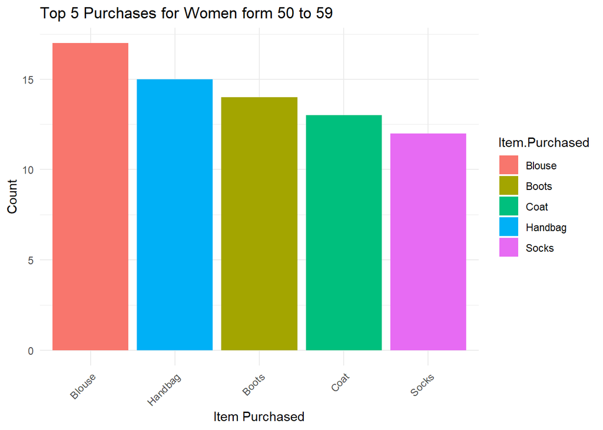

```r
#Top 5 purchases for women in the 50 to 59 age group.
top_5_purchases_women_50_59<-sqldf("select Category, `Item.Purchased`, count(`Item.Purchased`) as count,  avg(`Purchase.Amount..USD.`) as avg_price from df1 where (Age between 50 and 59) and Gender == 'Female' group by `Item.Purchased` order by count desc limit 5")
#View(top_5_purchases_women_50_59)

ggplot(top_5_purchases_women_50_59, aes(x = reorder(`Item.Purchased`, -count), y = count, fill = `Item.Purchased`)) +
  geom_bar(stat = "identity") +
  labs(title = "Top 5 Purchases for Women form 50 to 59", x = "Item Purchased", y = "Count") +
  theme_minimal() +
  theme(axis.text.x = element_text(angle = 45, hjust = 1))
```

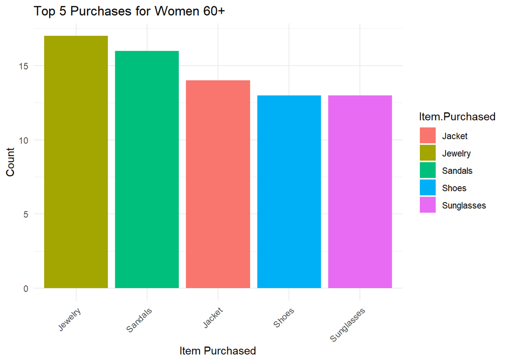

```r
#Top 5 purchases for women in the 60+ age group.
top_5_purchases_women_60<-sqldf("select Category, `Item.Purchased`, count(`Item.Purchased`) as count,  avg(`Purchase.Amount..USD.`) as avg_price from df1 where (Age >= 60) and Gender  == 'Female' group by `Item.Purchased` order by count desc limit 5")
#View(top_5_purchases_women_60)

ggplot(top_5_purchases_women_60, aes(x = reorder(`Item.Purchased`, -count), y = count, fill = `Item.Purchased`)) +
  geom_bar(stat = "identity") +
  labs(title = "Top 5 Purchases for Women 60+", x = "Item Purchased", y = "Count") +
  theme_minimal() +
  theme(axis.text.x = element_text(angle = 45, hjust = 1))
```

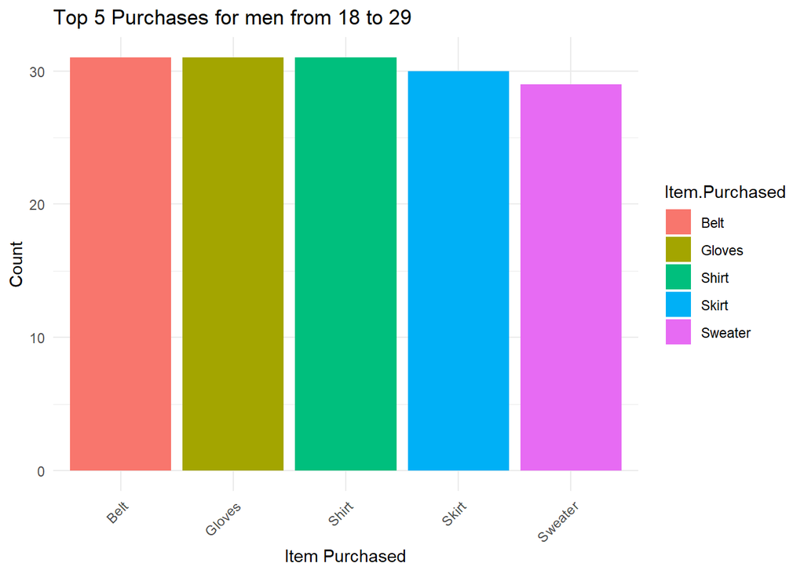

```r
#For Men
#Top 5 purchases for men in the 18 to 29 age group.
top_5_purchases_men_18_29<-sqldf("select Category, `Item.Purchased`, count(`Item.Purchased`) as count,  avg(`Purchase.Amount..USD.`) as avg_price from df1 where (Age between 18 and 29) and Gender == 'Male' group by `Item.Purchased` order by count desc limit 5")
#View(top_5_purchases_men_18_29)

ggplot(top_5_purchases_men_18_29, aes(x = reorder(`Item.Purchased`, -count), y = count, fill = `Item.Purchased`)) +
  geom_bar(stat = "identity") +
  labs(title = "Top 5 Purchases for men from 18 to 29", x = "Item Purchased", y = "Count") +
  theme_minimal() +
  theme(axis.text.x = element_text(angle = 45, hjust = 1))
```

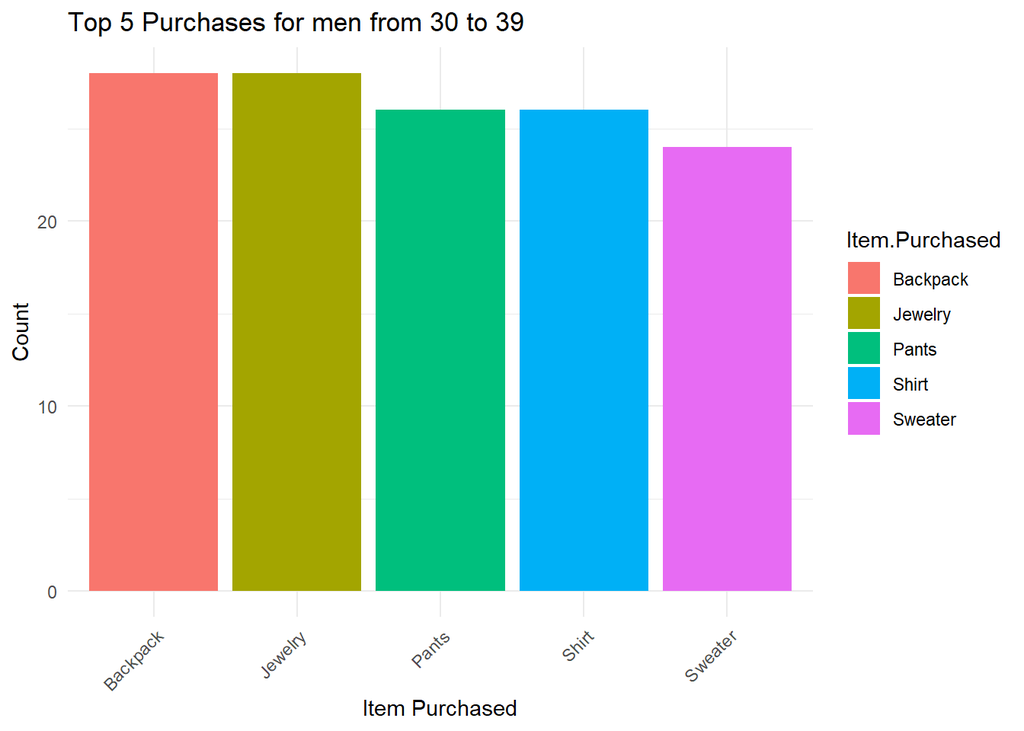

```r
#Top 5 purchases for men in the 30 to 39 age group.
top_5_purchases_men_30_39<-sqldf("select Category, `Item.Purchased`, count(`Item.Purchased`) as count,  avg(`Purchase.Amount..USD.`) as avg_price from df1 where (Age between 30 and 39) and Gender == 'Male' group by `Item.Purchased` order by count desc limit 5")
#View(top_5_purchases_men_30_39)

ggplot(top_5_purchases_men_30_39, aes(x = reorder(`Item.Purchased`, -count), y = count, fill = `Item.Purchased`)) +
  geom_bar(stat = "identity") +
  labs(title = "Top 5 Purchases for men from 30 to 39", x = "Item Purchased", y = "Count") +
  theme_minimal() +
  theme(axis.text.x = element_text(angle = 45, hjust = 1))
```

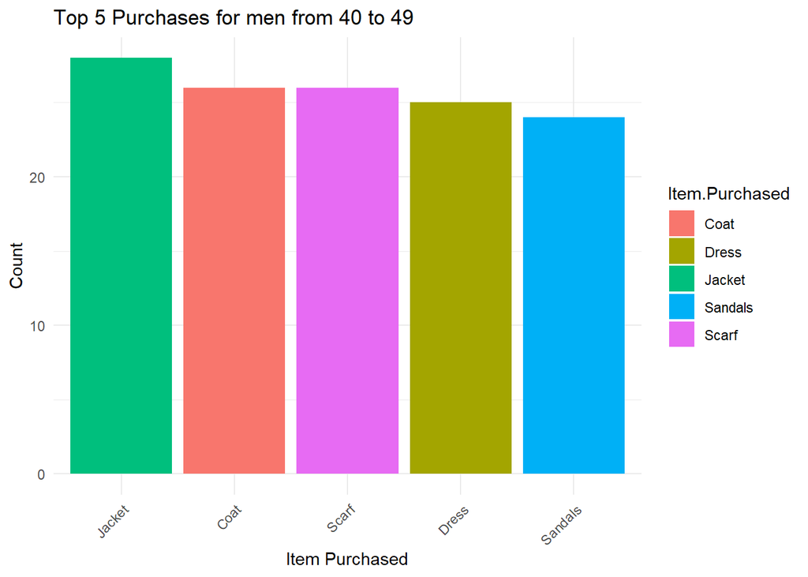

```r
#Top 5 purchases for men in the 40 to 49 age group.
top_5_purchases_men_40_49<-sqldf("select Category, `Item.Purchased`, count(`Item.Purchased`) as count,  avg(`Purchase.Amount..USD.`) as avg_price from df1 where (Age between 40 and 49) and Gender=='Male' group by `Item.Purchased` order by count desc limit 5")
#View(top_5_purchases_men_40_49)

ggplot(top_5_purchases_men_40_49, aes(x = reorder(`Item.Purchased`, -count), y = count, fill = `Item.Purchased`)) +
  geom_bar(stat = "identity") +
  labs(title = "Top 5 Purchases for men from 40 to 49", x = "Item Purchased", y = "Count") +
  theme_minimal() +
  theme(axis.text.x = element_text(angle = 45, hjust = 1))
```

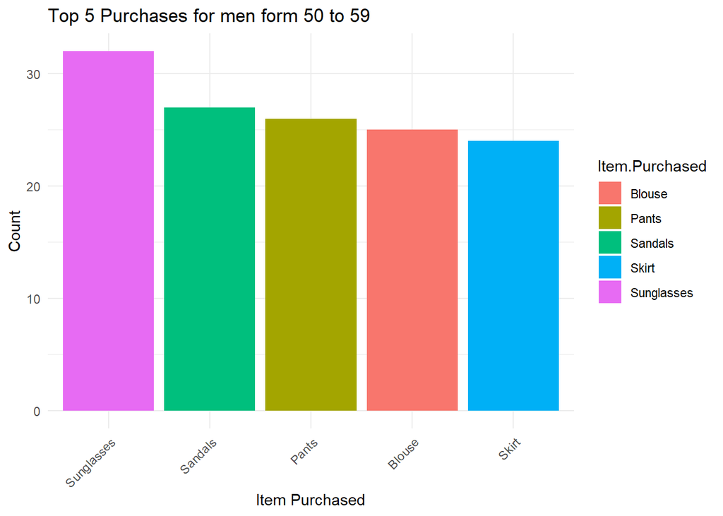

```r
#Top 5 purchases for men in the 50 to 59 age group.
top_5_purchases_men_50_59<-sqldf("select Category, `Item.Purchased`, count(`Item.Purchased`) as count,  avg(`Purchase.Amount..USD.`) as avg_price from df1 where (Age between 50 and 59) and Gender == 'Male' group by `Item.Purchased` order by count desc limit 5")
#View(top_5_purchases_men_50_59)

ggplot(top_5_purchases_men_50_59, aes(x = reorder(`Item.Purchased`, -count), y = count, fill = `Item.Purchased`)) +
  geom_bar(stat = "identity") +
  labs(title = "Top 5 Purchases for men form 50 to 59", x = "Item Purchased", y = "Count") +
  theme_minimal() +
  theme(axis.text.x = element_text(angle = 45, hjust = 1))
```

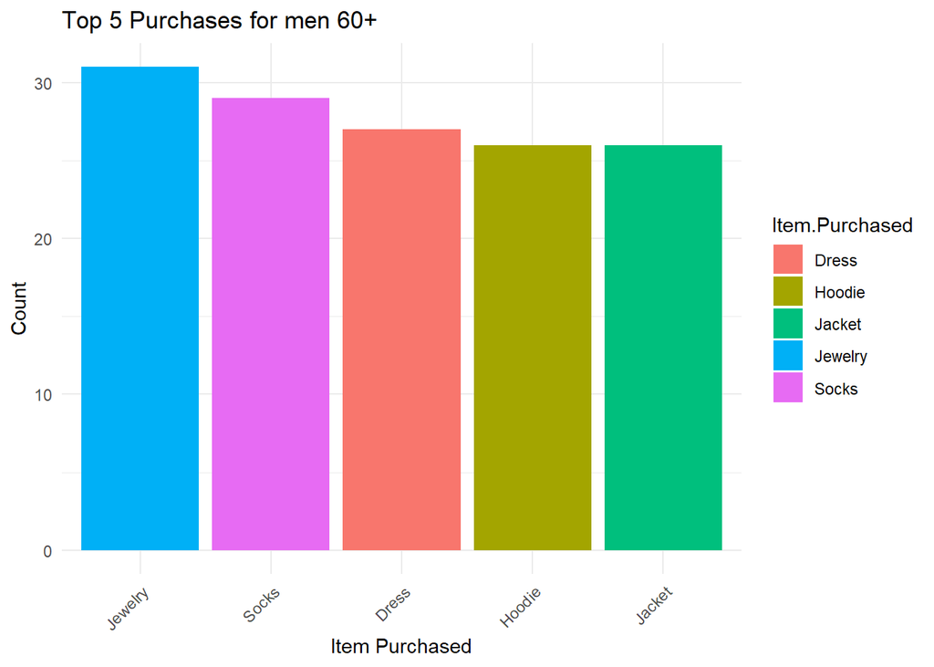

```r
#Top 5 purchases for men in the 60+ age group.
top_5_purchases_men_60<-sqldf("select Category, `Item.Purchased`, count(`Item.Purchased`) as count,  avg(`Purchase.Amount..USD.`) as avg_price from df1 where (Age >= 60) and Gender  == 'Male' group by `Item.Purchased` order by count desc limit 5")
#View(top_5_purchases_men_60)

ggplot(top_5_purchases_men_60, aes(x = reorder(`Item.Purchased`, -count), y = count, fill = `Item.Purchased`)) +
  geom_bar(stat = "identity") +
  labs(title = "Top 5 Purchases for men 60+", x = "Item Purchased", y = "Count") +
  theme_minimal() +
  theme(axis.text.x = element_text(angle = 45, hjust = 1))
```

Now we can take a look at which colors are the most popular :

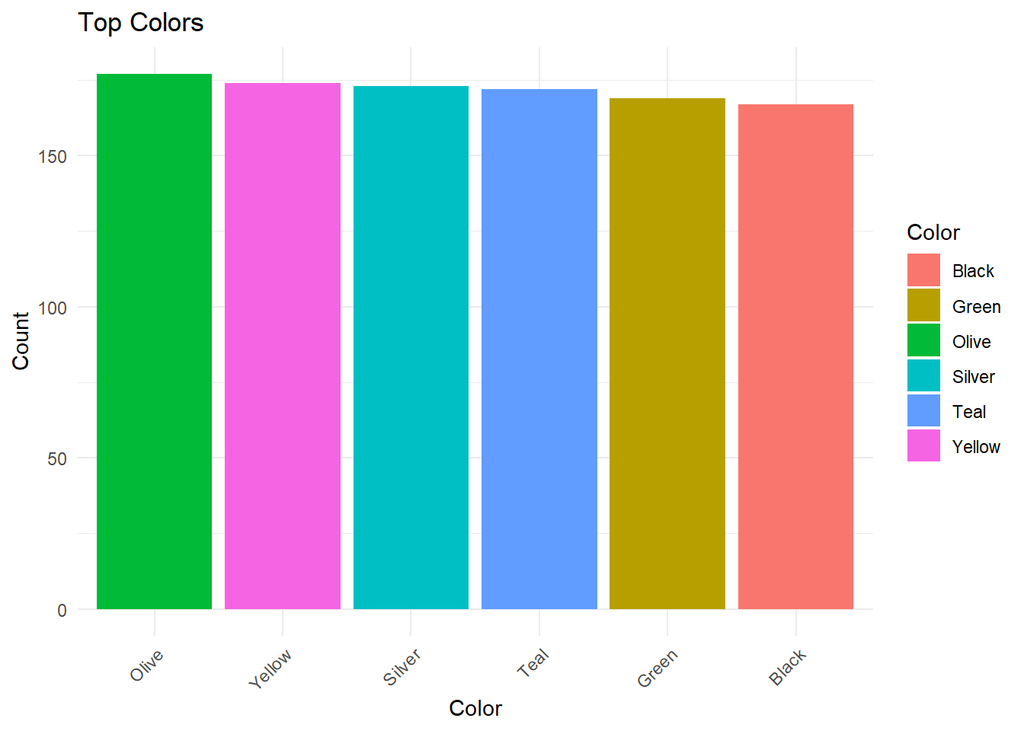

```r
top_colors = sqldf("select Color, count(Color) as count from df1 group by Color order by count desc limit 6")
#View(top_colors)

ggplot(top_colors, aes(x = reorder(Color, -count), y = count, fill = Color)) +
  geom_bar(stat = "identity") +
  labs(title = "Top Colors", x = "Color", y = "Count") +
  theme_minimal() +
  theme(axis.text.x = element_text(angle = 45, hjust = 1))
```

We can see the difference by gender:

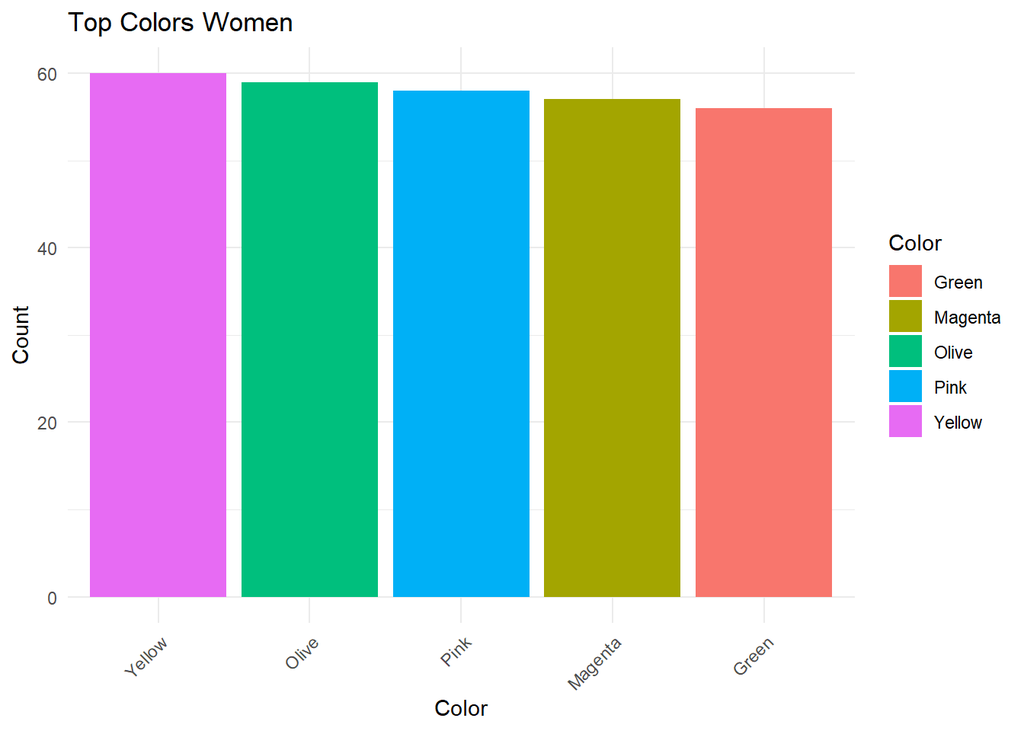

```r
top_color_women<-sqldf("select Color, count(Color) as count from df1 where Gender == 'Female' group by Color order by count(Color) desc limit 5")
#View(top_color_women)

ggplot(top_color_women, aes(x = reorder(Color, -count), y = count, fill = Color)) +
  geom_bar(stat = "identity") +
  labs(title = "Top Colors Women", x = "Color", y = "Count") +
  theme_minimal() +
  theme(axis.text.x = element_text(angle = 45, hjust = 1))
```

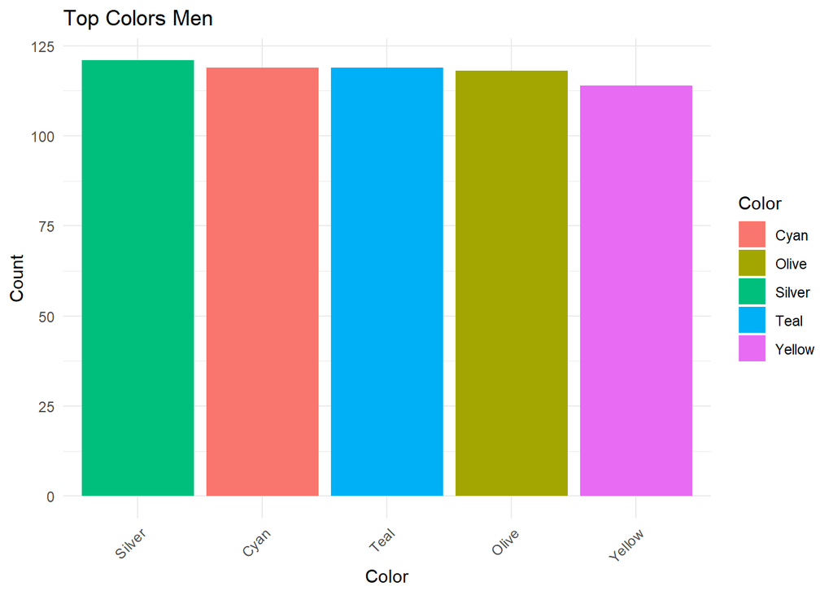

```r
top_color_men<-sqldf("select Color, count(Color) as count from df1 where Gender == 'Male' group by Color order by count(Color) desc limit 5")
#View(top_color_men)

ggplot(top_color_men, aes(x = reorder(Color, -count), y = count, fill = Color)) +
  geom_bar(stat = "identity") +
  labs(title = "Top Colors Men", x = "Color", y = "Count") +
  theme_minimal() +
  theme(axis.text.x = element_text(angle = 45, hjust = 1))
```

We can look at how this varies for age:

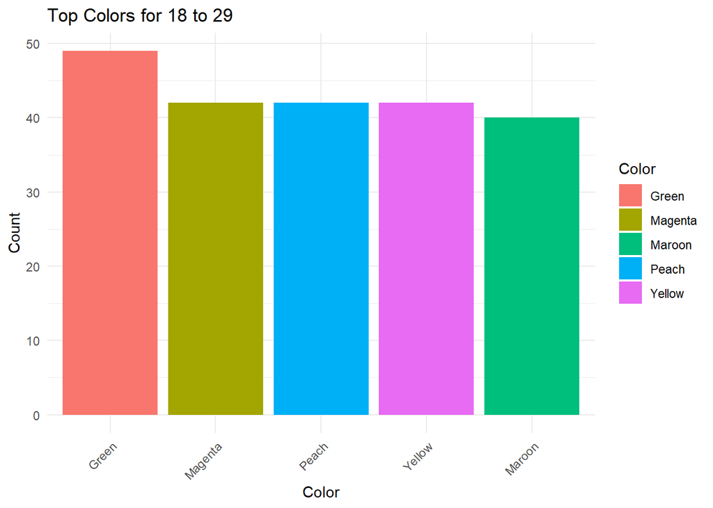

```r
#Top colors for the 18 to 29 age group.
top_colors_18_29<-sqldf("select Color, count(Color) as count from df1  where Age between 18 and 29 group by Color order by count(Color) desc limit 5")
#View(top_colors_18_29)

ggplot(top_colors_18_29, aes(x = reorder(Color, -count), y = count, fill = Color)) +
  geom_bar(stat = "identity") +
  labs(title = "Top Colors for 18 to 29", x = "Color", y = "Count") +
  theme_minimal() +
  theme(axis.text.x = element_text(angle = 45, hjust = 1))
```

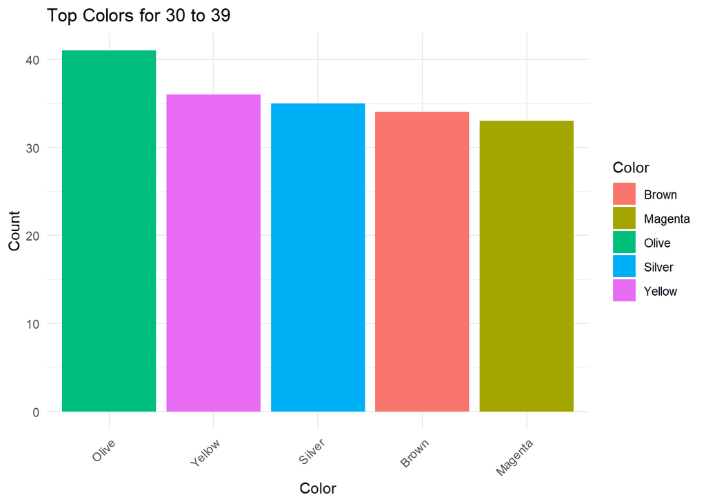

```r
#Top colors for the 30 to 39 age group.
top_colors_30_39<-sqldf("select Color, count(Color) as count from df1  where Age between 30 and 39 group by Color order by count(Color) desc limit 5")
#View(top_colors_30_39)

ggplot(top_colors_30_39, aes(x = reorder(Color, -count), y = count, fill = Color)) +
  geom_bar(stat = "identity") +
  labs(title = "Top Colors for 30 to 39", x = "Color", y = "Count") +
  theme_minimal() +
  theme(axis.text.x = element_text(angle = 45, hjust = 1))
```

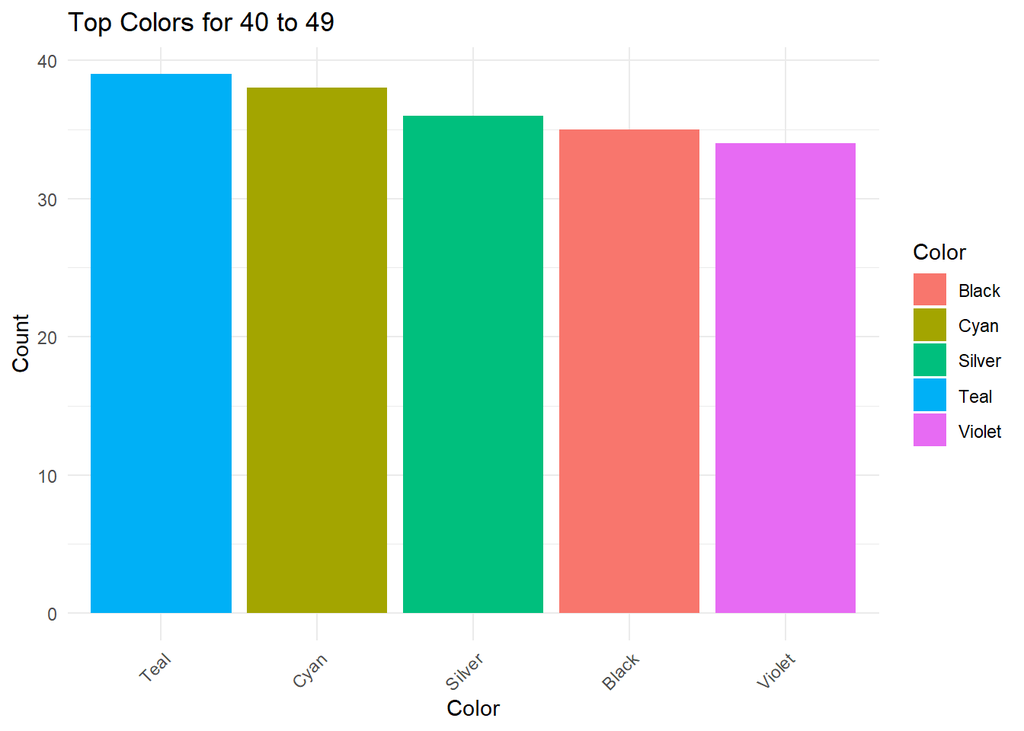

```r
#Top colors for the 40 to 49 age group.
top_colors_40_49<-sqldf("select Color, count(Color) as count from df1  where Age between 40 and 49 group by Color order by count(Color) desc limit 5")
#View(top_colors_40_49)

ggplot(top_colors_40_49, aes(x = reorder(Color, -count), y = count, fill = Color)) +
  geom_bar(stat = "identity") +
  labs(title = "Top Colors for 40 to 49", x = "Color", y = "Count") +
  theme_minimal() +
  theme(axis.text.x = element_text(angle = 45, hjust = 1))
```

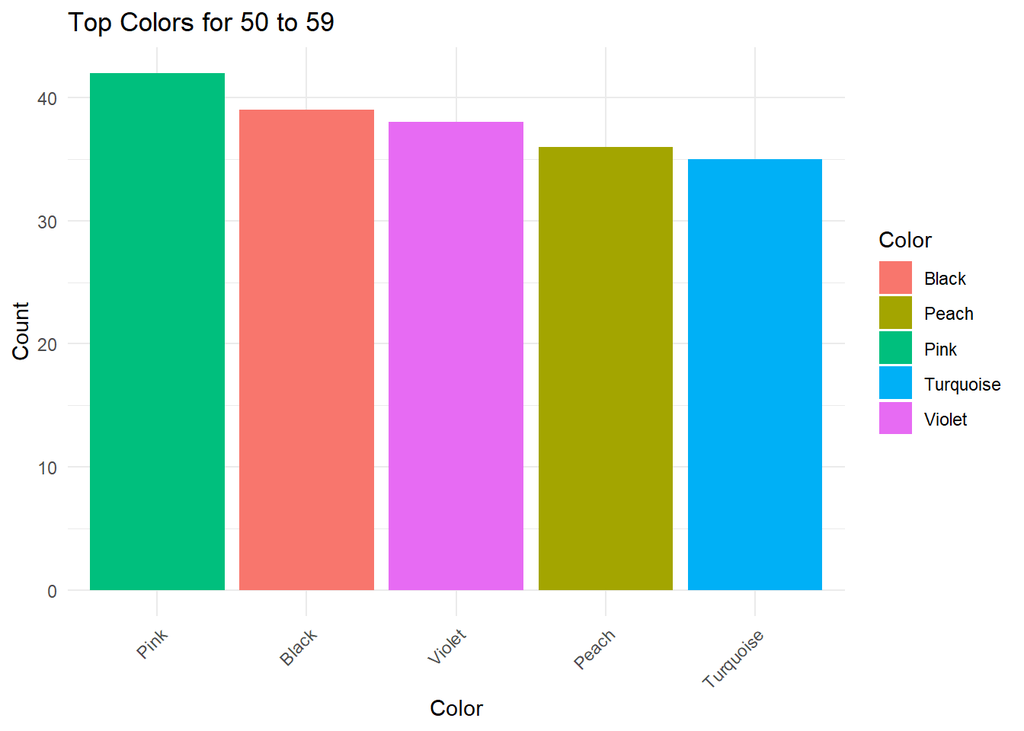

```r
#Top colors for the 50 to 59 age group.
top_colors_50_59<-sqldf("select Color, count(Color) as count from df1  where Age between 50 and 59 group by Color order by count(Color) desc limit 5")
#View(top_colors_50_59)

ggplot(top_colors_50_59, aes(x = reorder(Color, -count), y = count, fill = Color)) +
  geom_bar(stat = "identity") +
  labs(title = "Top Colors for 50 to 59", x = "Color", y = "Count") +
  theme_minimal() +
  theme(axis.text.x = element_text(angle = 45, hjust = 1))
```

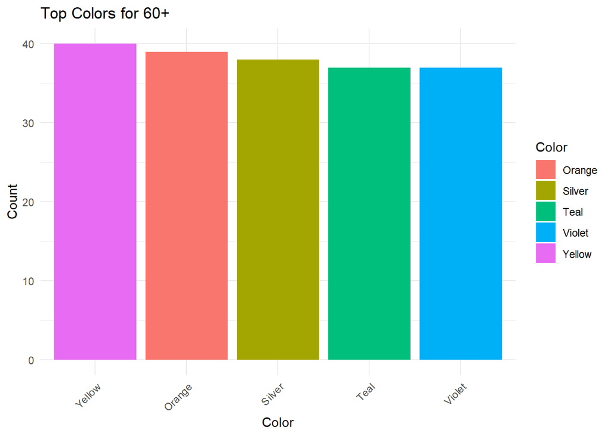

```r
#Top colors for the 60+ age group.
top_colors_60<-sqldf("select Color, count(Color) as count from df1  where Age >= 60 group by Color order by count(Color) desc limit 5")
#View(top_colors_60)

ggplot(top_colors_60, aes(x = reorder(Color, -count), y = count, fill = Color)) +
  geom_bar(stat = "identity") +
  labs(title = "Top Colors for 60+", x = "Color", y = "Count") +
  theme_minimal() +
  theme(axis.text.x = element_text(angle = 45, hjust = 1))
```

We can look at which seasons have the most purchases:

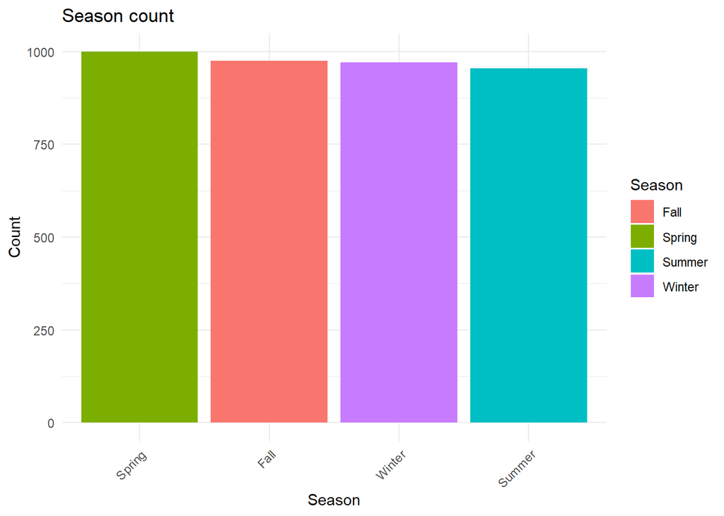

```r
seasons = sqldf("select Season, count(Season) as count from df1 group by Season order by count desc")
#View(seasons)

ggplot(seasons, aes(x = reorder(Season, -count), y = count, fill = Season)) +
  geom_bar(stat = "identity") +
  labs(title = "Season count", x = "Season", y = "Count") +
  theme_minimal() +
  theme(axis.text.x = element_text(angle = 45, hjust = 1))
```

Spring has the most purchases.